# Fit to Exposures

Here, I vary the parameter values for each model (one iteration per parameter combination) and evaluate how well they reproduce the observed exposures. The fit is measured at the domain level as the average absolute difference in exposure percentage (the y-axis in Figure 2 of our paper) between the observed and simulated exposures. For each parameter combination, I then average this measure across the top 10 most conservative and top 10 most liberal domains. Because exposure percentages are higher for more popular domains, this approach implicitly gives more weight to those domains.

Smaller values of the fit measure indicate a closer match between the observed and simulated exposures.

**Key takeaways:**

1. To speed up computation, I used `10^5` alters per ego percentile instead of `10^6` as in previous runs. As a result, the simulated exposures are still somewhat noisy; I am now rerunning the code with `10^6` alters.
2. The level of homophily that best fits the exposure data is much higher than the level that best fits the network structure, as expected. In the new runs, I increased the upper limit of the homophily parameter to 4 to try to capture the lower bound of model fits (best fit).
3. The best-fitting asymmetric model simulation so far is the symmetric one (`k = 0`). If this result holds in the new simulations, it supports our argument.

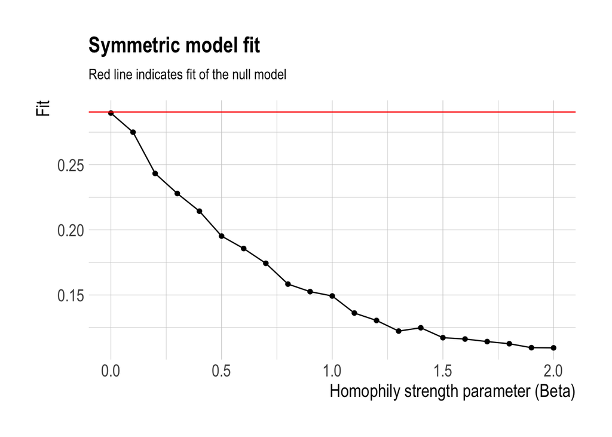

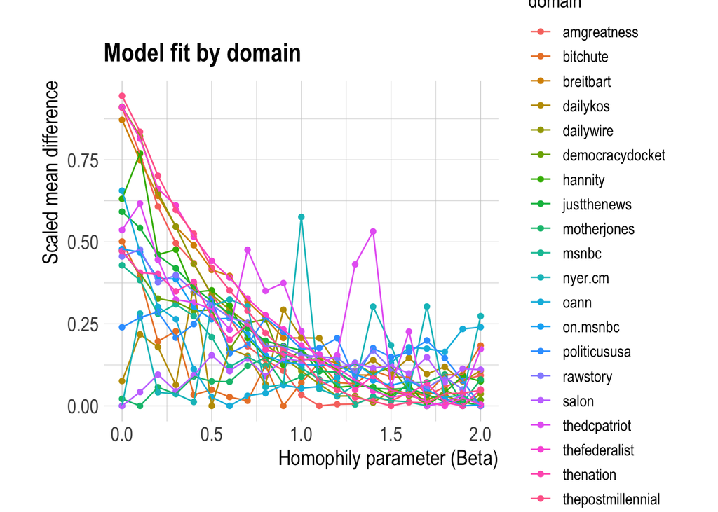

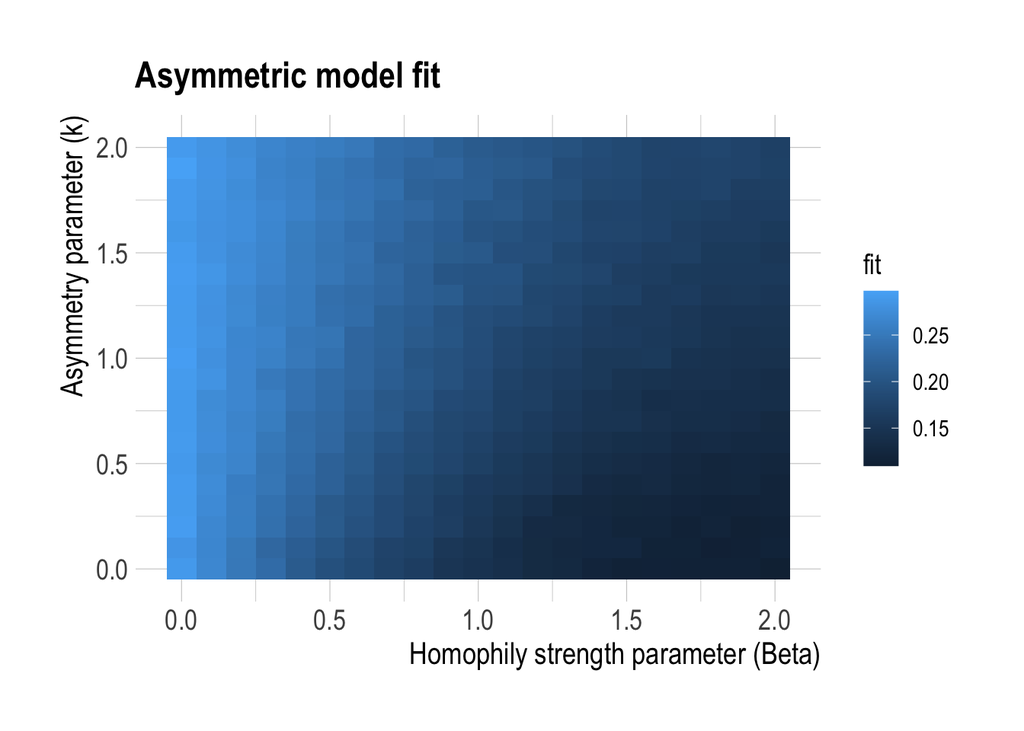

## Best fitting simulations

Here I take the best fitting simulation for each model and plot the simulated exposures against the observed ones.

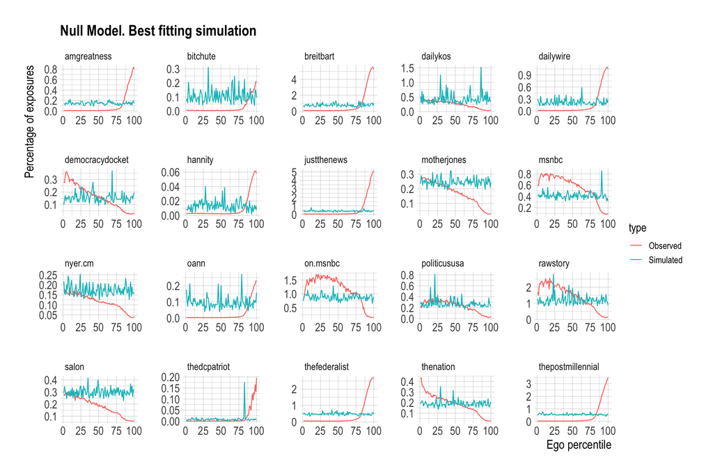

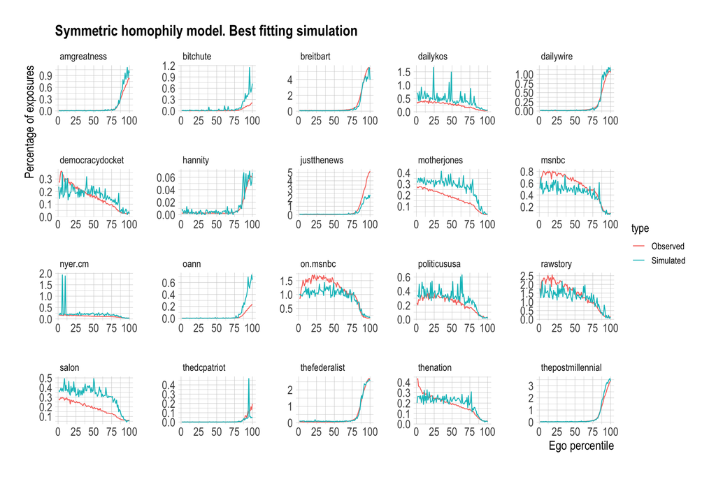

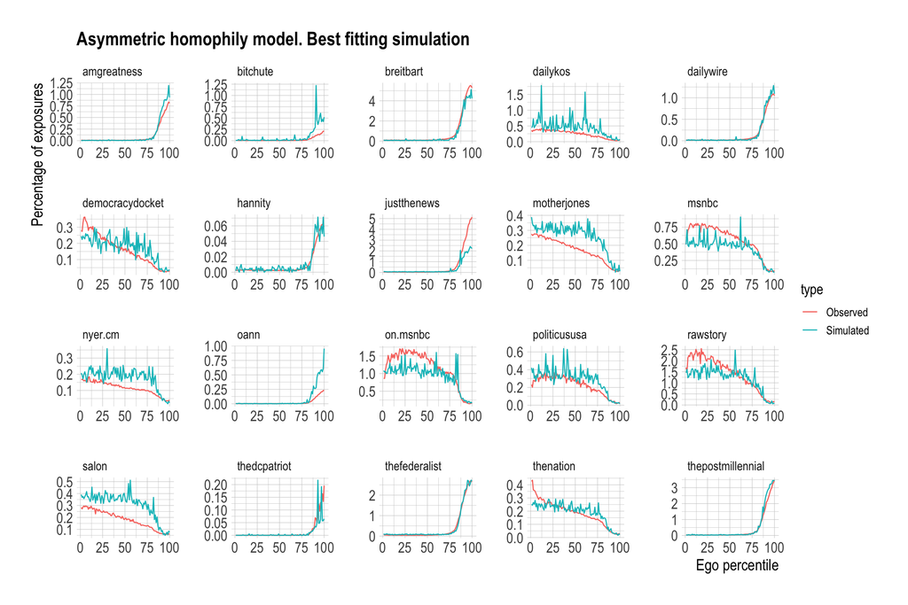